# hw5

1. Get the Data:

```r
if (file.exists("alcohol.rds")) {
  data <- readRDS("alcohol.rds")
} else {
  url <- "https://xdaiisu.github.io/ds202materials/data/ames.csv"
  data <- readr::read_csv(url)
  saveRDS(data, file="alcohol.rds")
}
```

2. Data cleaning: -extract geographic latitude and longitude from the variable Store Location

```r
library(tidyverse)
dataNew <- data %>% separate(`Store Location`, c("address1", "address2", "coords"), sep = "\n") %>% select(-address1, -address2) %>% mutate(coords = gsub("[()]", "", coords)) %>% separate(coords, c("Latitude", "Longitude"), sep = ",")
```

-Check variable types. Pick five variables that need to be converted to a different type and fix those.

```r
str(dataNew)
```

```
## Classes 'tbl_df', 'tbl' and 'data.frame':    382033 obs. of  25 variables:
##  $ Invoice/Item Number  : chr  "INV-15386000001" "INV-15386000002" "INV-15386200001" "INV-15386600001" ...
##  $ Date                 : chr  "10/31/2018" "10/31/2018" "10/31/2018" "10/31/2018" ...
##  $ Store Number         : num  4129 4129 4129 4129 3524 ...
##  $ Store Name           : chr  "Cyclone Liquors" "Cyclone Liquors" "Cyclone Liquors" "Cyclone Liquors" ...
##  $ Address              : chr  "626 Lincoln Way" "626 Lincoln Way" "626 Lincoln Way" "626 Lincoln Way" ...
##  $ City                 : chr  "Ames" "Ames" "Ames" "Ames" ...
##  $ Zip Code             : num  50010 50010 50010 50010 50010 ...
##  $ Latitude             : chr  "42.022854" "42.022854" "42.022854" "42.022854" ...
##  $ Longitude            : chr  " -93.618911" " -93.618911" " -93.618911" " -93.618911" ...
##  $ County Number        : num  85 85 85 85 85 85 85 85 85 85 ...
##  $ County               : chr  "STORY" "STORY" "STORY" "STORY" ...
##  $ Category             : num  1031100 1062400 1022200 1022200 1901200 ...
##  $ Category Name        : chr  "American Vodkas" "Spiced Rum" "100% Agave Tequila" "100% Agave Tequila" ...
##  $ Vendor Number        : chr  "301" "260" "410" "260" ...
##  $ Vendor Name          : chr  "FIFTH GENERATION INC" "DIAGEO AMERICAS" "Patron Spirits Company" "DIAGEO AMERICAS" ...
##  $ Item Number          : num  38177 43337 88296 87485 936859 ...
##  $ Item Description     : chr  "Titos Handmade Vodka" "Captain Morgan Spiced Rum" "Patron Tequila Silver" "Don Julio Blanco Tequila" ...
##  $ Pack                 : num  12 12 12 6 6 6 12 12 12 6 ...
##  $ Bottle Volume (ml)   : num  1000 1000 750 750 1750 ...
##  $ State Bottle Cost    : num  12.67 11.75 27.5 28.99 8.51 ...
##  $ State Bottle Retail  : num  19 17.6 41.2 43.5 12.8 ...
##  $ Bottles Sold         : num  24 12 12 6 360 6 12 288 24 18 ...
##  $ Sale (Dollars)       : num  456 212 495 261 4597 ...
##  $ Volume Sold (Liters) : num  24 12 9 4.5 630 6.75 12 288 18 31.5 ...
##  $ Volume Sold (Gallons): num  6.34 3.17 2.37 1.18 166.42 ...
```

```r
dataCleaned <- dataNew
# Longitude as number
dataCleaned$Longitude <- as.double(dataNew$Longitude, round = FALSE)
# Latitude as number
dataCleaned$Latitude <- as.double(dataNew$Latitude, digits = 10)
# Date (using Lubridate)
library(lubridate)
dataCleaned$Date <- mdy(dataCleaned$Date)
#vendor Number as number
dataCleaned$`Vendor Number` <- as.numeric(dataCleaned$`Vendor Number`)
#pack as integer, because you can not have a decimal in a pack.
dataCleaned$Pack <- as.integer(dataCleaned$Pack)
str(dataNew)
```

```
## Classes 'tbl_df', 'tbl' and 'data.frame':    382033 obs. of  25 variables:
##  $ Invoice/Item Number  : chr  "INV-15386000001" "INV-15386000002" "INV-15386200001" "INV-15386600001" ...
##  $ Date                 : chr  "10/31/2018" "10/31/2018" "10/31/2018" "10/31/2018" ...
##  $ Store Number         : num  4129 4129 4129 4129 3524 ...
##  $ Store Name           : chr  "Cyclone Liquors" "Cyclone Liquors" "Cyclone Liquors" "Cyclone Liquors" ...
##  $ Address              : chr  "626 Lincoln Way" "626 Lincoln Way" "626 Lincoln Way" "626 Lincoln Way" ...
##  $ City                 : chr  "Ames" "Ames" "Ames" "Ames" ...
##  $ Zip Code             : num  50010 50010 50010 50010 50010 ...
##  $ Latitude             : chr  "42.022854" "42.022854" "42.022854" "42.022854" ...
##  $ Longitude            : chr  " -93.618911" " -93.618911" " -93.618911" " -93.618911" ...
##  $ County Number        : num  85 85 85 85 85 85 85 85 85 85 ...
##  $ County               : chr  "STORY" "STORY" "STORY" "STORY" ...
##  $ Category             : num  1031100 1062400 1022200 1022200 1901200 ...
##  $ Category Name        : chr  "American Vodkas" "Spiced Rum" "100% Agave Tequila" "100% Agave Tequila" ...
##  $ Vendor Number        : chr  "301" "260" "410" "260" ...
##  $ Vendor Name          : chr  "FIFTH GENERATION INC" "DIAGEO AMERICAS" "Patron Spirits Company" "DIAGEO AMERICAS" ...
##  $ Item Number          : num  38177 43337 88296 87485 936859 ...
##  $ Item Description     : chr  "Titos Handmade Vodka" "Captain Morgan Spiced Rum" "Patron Tequila Silver" "Don Julio Blanco Tequila" ...
##  $ Pack                 : num  12 12 12 6 6 6 12 12 12 6 ...
##  $ Bottle Volume (ml)   : num  1000 1000 750 750 1750 ...
##  $ State Bottle Cost    : num  12.67 11.75 27.5 28.99 8.51 ...
##  $ State Bottle Retail  : num  19 17.6 41.2 43.5 12.8 ...
##  $ Bottles Sold         : num  24 12 12 6 360 6 12 288 24 18 ...
##  $ Sale (Dollars)       : num  456 212 495 261 4597 ...
##  $ Volume Sold (Liters) : num  24 12 9 4.5 630 6.75 12 288 18 31.5 ...
##  $ Volume Sold (Gallons): num  6.34 3.17 2.37 1.18 166.42 ...
```

```r
str(dataCleaned)
```

```
## Classes 'tbl_df', 'tbl' and 'data.frame':    382033 obs. of  25 variables:
##  $ Invoice/Item Number  : chr  "INV-15386000001" "INV-15386000002" "INV-15386200001" "INV-15386600001" ...
##  $ Date                 : Date, format: "2018-10-31" "2018-10-31" ...
##  $ Store Number         : num  4129 4129 4129 4129 3524 ...
##  $ Store Name           : chr  "Cyclone Liquors" "Cyclone Liquors" "Cyclone Liquors" "Cyclone Liquors" ...
##  $ Address              : chr  "626 Lincoln Way" "626 Lincoln Way" "626 Lincoln Way" "626 Lincoln Way" ...
##  $ City                 : chr  "Ames" "Ames" "Ames" "Ames" ...
##  $ Zip Code             : num  50010 50010 50010 50010 50010 ...
##  $ Latitude             : num  42 42 42 42 42 ...
##  $ Longitude            : num  -93.6 -93.6 -93.6 -93.6 -93.6 ...
##  $ County Number        : num  85 85 85 85 85 85 85 85 85 85 ...
##  $ County               : chr  "STORY" "STORY" "STORY" "STORY" ...
##  $ Category             : num  1031100 1062400 1022200 1022200 1901200 ...
##  $ Category Name        : chr  "American Vodkas" "Spiced Rum" "100% Agave Tequila" "100% Agave Tequila" ...
##  $ Vendor Number        : num  301 260 410 260 421 260 370 260 434 260 ...
##  $ Vendor Name          : chr  "FIFTH GENERATION INC" "DIAGEO AMERICAS" "Patron Spirits Company" "DIAGEO AMERICAS" ...
##  $ Item Number          : num  38177 43337 88296 87485 936859 ...
##  $ Item Description     : chr  "Titos Handmade Vodka" "Captain Morgan Spiced Rum" "Patron Tequila Silver" "Don Julio Blanco Tequila" ...
##  $ Pack                 : int  12 12 12 6 6 6 12 12 12 6 ...
##  $ Bottle Volume (ml)   : num  1000 1000 750 750 1750 ...
##  $ State Bottle Cost    : num  12.67 11.75 27.5 28.99 8.51 ...
##  $ State Bottle Retail  : num  19 17.6 41.2 43.5 12.8 ...
##  $ Bottles Sold         : num  24 12 12 6 360 6 12 288 24 18 ...
##  $ Sale (Dollars)       : num  456 212 495 261 4597 ...
##  $ Volume Sold (Liters) : num  24 12 9 4.5 630 6.75 12 288 18 31.5 ...
##  $ Volume Sold (Gallons): num  6.34 3.17 2.37 1.18 166.42 ...
```

-Extract year, month and day from the variable Date

```r
dataCleaned$`Day of Year`<-yday(dataCleaned$Date)
dataCleaned$Year <- year(dataCleaned$Date)
dataCleaned$Month <- month(dataCleaned$Date)
dataCleaned$Day <- day(dataCleaned$Date)
```

3. First overview: -Plot a scatterplot of lat and long of store locations.

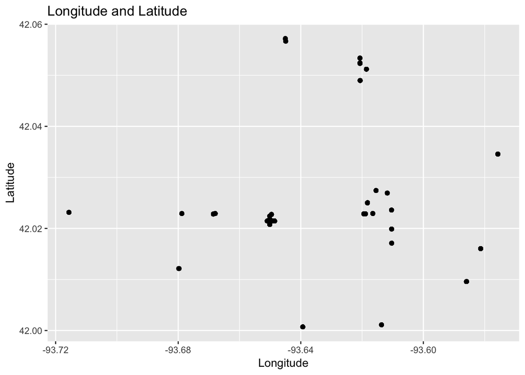

```r
ggplot(dataCleaned, aes(x=Longitude, y=Latitude)) + geom_point() + ggtitle("Longitude and Latitude")
```

-Provide a visual breakdown of the liquor category (by Category Name). Include volume sold in the breakdown.

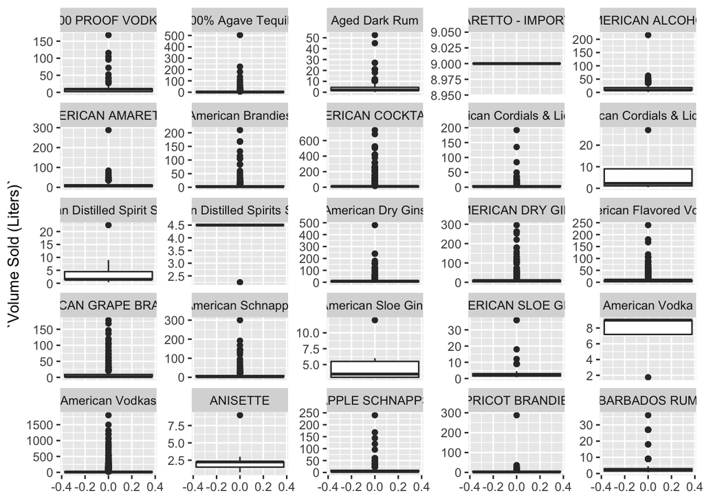

```r
library(ggforce)


ggplot(dataCleaned, aes(y=`Volume Sold (Liters)`)) + geom_boxplot() + facet_wrap_paginate(~`Category Name`, ncol=5, nrow=5, scales="free_y", page = 1 )
```

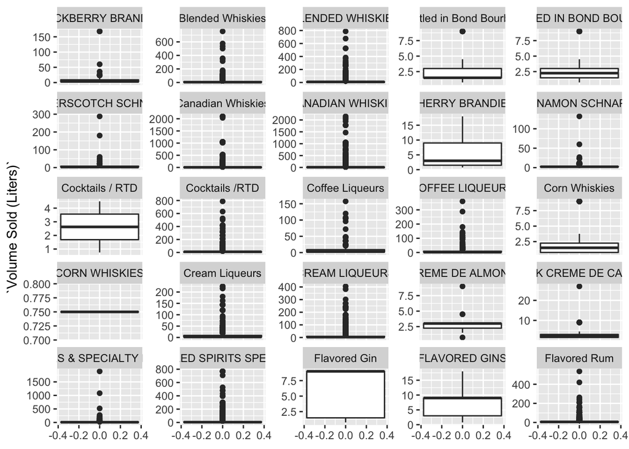

```r
ggplot(dataCleaned, aes(y=`Volume Sold (Liters)`)) + geom_boxplot() + facet_wrap_paginate(~`Category Name`, ncol=5, nrow=5, scales="free_y", page = 2 )
```

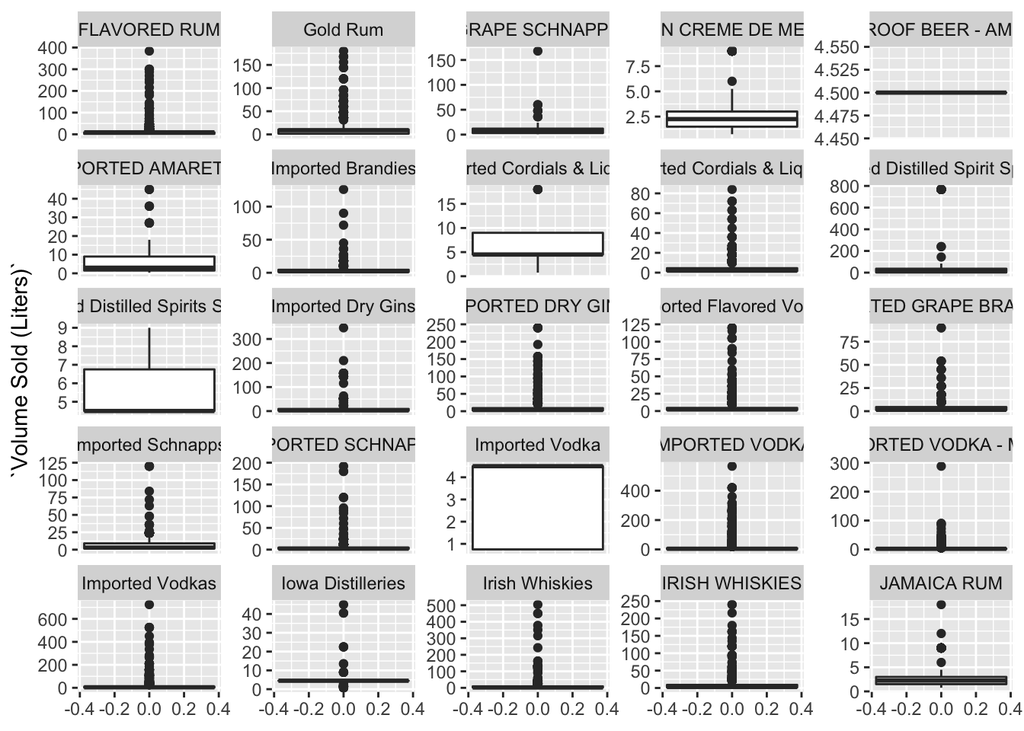

```r
ggplot(dataCleaned, aes(y=`Volume Sold (Liters)`)) + geom_boxplot() + facet_wrap_paginate(~`Category Name`, ncol=5, nrow=5, scales="free_y", page = 3 )
```

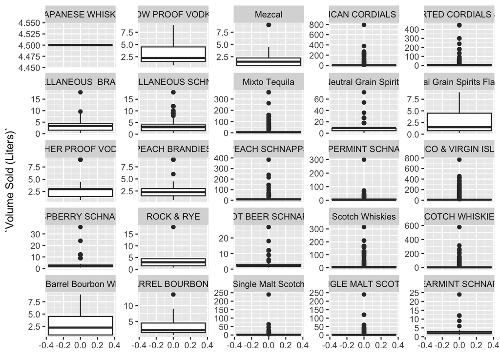

```r
ggplot(dataCleaned, aes(y=`Volume Sold (Liters)`)) + geom_boxplot() + facet_wrap_paginate(~`Category Name`, ncol=5, nrow=5, scales="free_y", page = 4 )
```

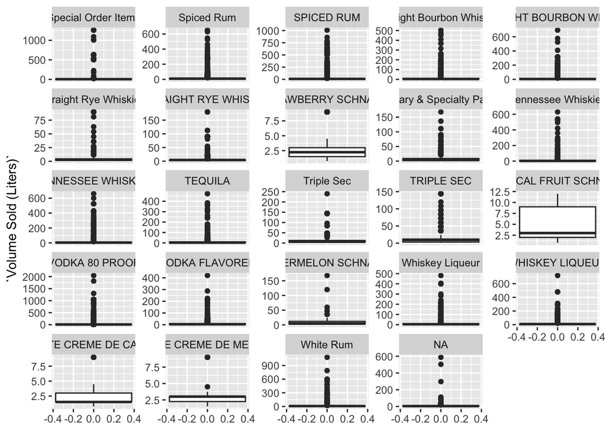

```r
ggplot(dataCleaned, aes(y=`Volume Sold (Liters)`)) + geom_boxplot() + facet_wrap_paginate(~`Category Name`, ncol=5, nrow=5, scales="free_y", page = 5 )
```

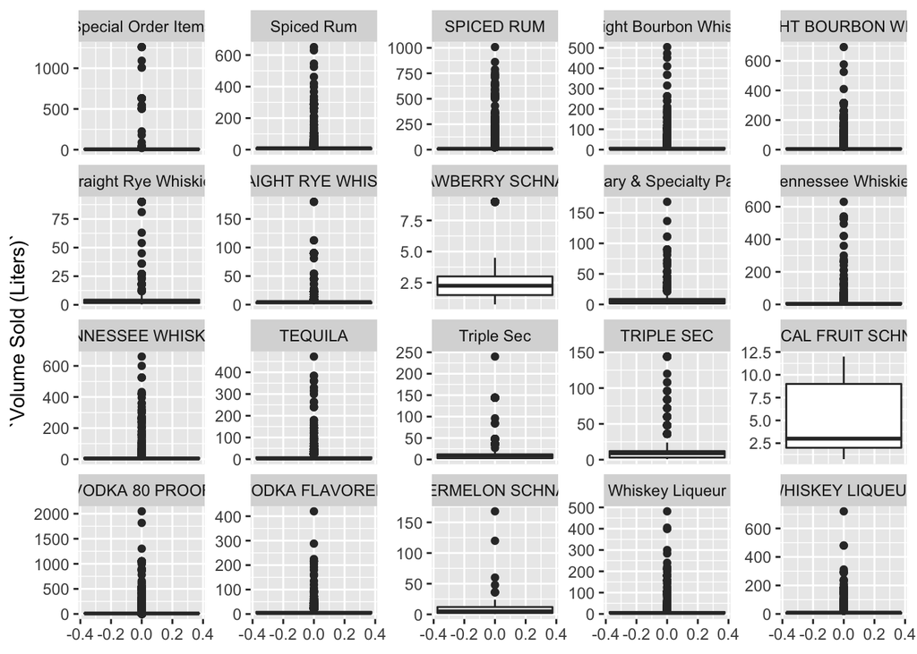

```r
ggplot(dataCleaned, aes(y=`Volume Sold (Liters)`)) + geom_boxplot() + facet_wrap_paginate(~`Category Name`, ncol=5, nrow=4, scales="free_y", page = 6 )
```

4. Find the daily sales liquor sales in Ames in 2018.

```r
Ames2018 <- filter(dataCleaned, Year == "2018")
liquor.grp.year <- group_by(Ames2018, `Day of Year`)
summarise(liquor.grp.year, sum(`Sale (Dollars)`))
```

```
## # A tibble: 146 x 2
##    `Day of Year` `sum(\`Sale (Dollars)\`)`
##            <dbl>                     <dbl>
##  1             3                  104862.
##  2             5                   31048.
##  3            10                  141905.
##  4            12                   17881.
##  5            17                  159217.
##  6            18                      11.2
##  7            19                   15664.
##  8            22                       0
##  9            24                  124823.
## 10            25                      20.8
## # … with 136 more rows
```

Summarize number of sales, volume of liquor sold and amount of money spent.

```r
sale.count <- group_by(dataCleaned, `Day of Year`)
tally(sale.count)
```

```
## # A tibble: 365 x 2
##    `Day of Year`     n
##            <dbl> <int>
##  1             2   199
##  2             3  2145
##  3             4  1045
##  4             5   933
##  5             6   224
##  6             7  1287
##  7             8  1015
##  8             9  1403
##  9            10  1380
## 10            11  1207
## # … with 355 more rows
```

```r
summarise(sale.count, sum(`Volume Sold (Liters)`), sum(`Day of Year`), sum(`Sale (Dollars)`))
```

```
## # A tibble: 365 x 4
##    `Day of Year` `sum(\`Volume Sold … `sum(\`Day of Yea… `sum(\`Sale (Doll…
##            <dbl>                <dbl>              <dbl>              <dbl>
##  1             2                1214.                398             17679.
##  2             3               15421.               6435            246547.
##  3             4                7995.               4180            129992.
##  4             5                6098.               4665             88479.
##  5             6                1575.               1344             21430.
##  6             7               10676.               9009            154379.
##  7             8               11314.               8120            155763.
##  8             9               10934.              12627            151333.
##  9            10               13904.              13800            189713.
## 10            11                8786.              13277            133764.
## # … with 355 more rows
```

Plot volume sold by day (use a scatterplot of volume by day and facet by month). Describe any patterns.

```r
library(dplyr)
?facet_grid
VolumeSold <- group_by(dataCleaned, `Day of Year`)
VolumeSold
```

```
## # A tibble: 382,033 x 29
## # Groups:   Day of Year [365]
##    `Invoice/Item N… Date       `Store Number` `Store Name` Address City
##    <chr>            <date>              <dbl> <chr>        <chr>   <chr>
##  1 INV-15386000001  2018-10-31           4129 Cyclone Liq… 626 Li… Ames
##  2 INV-15386000002  2018-10-31           4129 Cyclone Liq… 626 Li… Ames
##  3 INV-15386200001  2018-10-31           4129 Cyclone Liq… 626 Li… Ames
##  4 INV-15386600001  2018-10-31           4129 Cyclone Liq… 626 Li… Ames
##  5 INV-15397500001  2018-10-31           3524 Sam's Club … 305 Ai… Ames
##  6 INV-15397600001  2018-10-31           3524 Sam's Club … 305 Ai… Ames
##  7 INV-15397700001  2018-10-31           3524 Sam's Club … 305 Ai… Ames
##  8 INV-15397700002  2018-10-31           3524 Sam's Club … 305 Ai… Ames
##  9 INV-15397700003  2018-10-31           3524 Sam's Club … 305 Ai… Ames
## 10 INV-15397700004  2018-10-31           3524 Sam's Club … 305 Ai… Ames
## # … with 382,023 more rows, and 23 more variables: `Zip Code` <dbl>,
## #   Latitude <dbl>, Longitude <dbl>, `County Number` <dbl>, County <chr>,
## #   Category <dbl>, `Category Name` <chr>, `Vendor Number` <dbl>, `Vendor
## #   Name` <chr>, `Item Number` <dbl>, `Item Description` <chr>,
## #   Pack <int>, `Bottle Volume (ml)` <dbl>, `State Bottle Cost` <dbl>,
## #   `State Bottle Retail` <dbl>, `Bottles Sold` <dbl>, `Sale
## #   (Dollars)` <dbl>, `Volume Sold (Liters)` <dbl>, `Volume Sold
## #   (Gallons)` <dbl>, `Day of Year` <dbl>, Year <dbl>, Month <dbl>,
## #   Day <int>
```

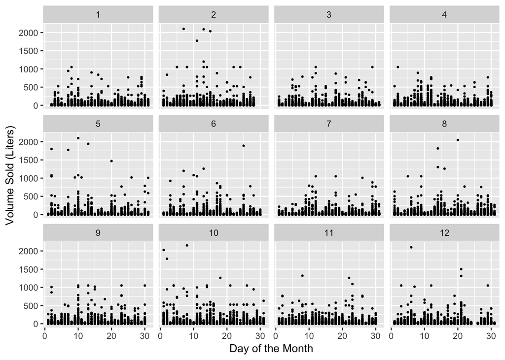

```r
ggplot(VolumeSold, aes(x=VolumeSold$Day, y=VolumeSold$`Volume Sold (Liters)`)) +geom_point(size=.5) + facet_wrap(~Month) + xlab("Day of the Month") + ylab("Volume Sold (Liters)")
```

Find the dates for ISU football home games in Fall 2018. Can you see a pattern?

```r
#9/1/2018 HOME
#9/8/2018
#9/15/2018 HOME
#9/22/2018 HOME
#9/29/2018
#10/6/2018
#10/13/2018 HOME
#10/27/2018 HOME
#11/3/2018
#11/10/2018 HOME
#11/17/2018
#11/24/2018 HOME
#12/1/2018
```